# In-class Exercise Lecture 8

01939418

17/11/2020

## Instruction

- Complete this RMarkdown file and “Knit” the HTML output (saved as **Lecture_8_YOUR_CID_NUMBER.html**) and upload to the Hub before the deadline.
- Change the author property in the YAML header above to your CID number.
- For this exercise, we will use `flights` dataset from `nycflights13` package. Install the `nycflights13` if you have not installed yet. This is a dataset of all flights that departed NYC (JFK, LGA or EWR) in 2013.
- To complete this exercise, make sure you have installed the tidyverse package. `install.packages("tidyverse")`

### Filtering

Find the number of flights that:

```r
# Had an arrival delay of two or more hours
# [1] 10200
nrow(filter(flights,arr_delay>=120))
```

```
## [1] 10200
```

```r
# Flew to Houston (IAH or HOU)
# [1] 9313
nrow(filter(flights,dest %in% c('IAH','HOU')))
```

```
## [1] 9313
```

```r
# Were operated by United, American, or Delta
# [1] 139504
nrow(filter(flights,carrier %in% c('AA','UA','DL')))
```

```
## [1] 139504
```

```r
# Departed in summer (July, August, and September) and have missing departure time values
# [1] 1878
nrow(filter(flights,is.na(dep_time) & month %in% c(7,8,9)))
```

```
## [1] 1878
```

```r
# Arrived more than two hours late, but didn’t leave late
# [1] 29
nrow(filter(flights,arr_delay>120 & dep_delay<=0))
```

```
## [1] 29
```

```r
# Were delayed by at least an hour, but made up over 30 minutes in flight
# [1] 2074
nrow(filter(flights,dep_delay>=60 & arr_delay<=(dep_delay-30)))
```

```
## [1] 2074
```

## Sorting

List the first 3 rows of the resulting dataframe. The outputs shown here only list the first 9 columns and may not show the column that was sorted on.

```r
# Sort flights to find the most delayed flights
#    year month   day dep_time sched_dep_time dep_delay arr_time sched_arr_time arr_delay
#   <int> <int> <int>    <int>          <int>     <dbl>    <int>          <int>     <dbl>
# 1  2013     1     9      641            900      1301     1242           1530      1272
# 2  2013     6    15     1432           1935      1137     1607           2120      1127
# 3  2013     1    10     1121           1635      1126     1239           1810      1109
arranged_data = arrange(flights,desc(arr_delay))
arranged_data[c(1:3),c(1:9)]
```

```
## # A tibble: 3 x 9
##    year month   day dep_time sched_dep_time dep_delay arr_time sched_arr_time
##   <int> <int> <int>    <int>          <int>     <dbl>    <int>          <int>
## 1  2013     1     9      641            900      1301     1242           1530
## 2  2013     6    15     1432           1935      1137     1607           2120
## 3  2013     1    10     1121           1635      1126     1239           1810
## # ... with 1 more variable: arr_delay <dbl>
```

```r
# Find the flights that left earliest

#    year month   day dep_time sched_dep_time dep_delay arr_time sched_arr_time arr_delay
#   <int> <int> <int>    <int>          <int>     <dbl>    <int>          <int>     <dbl>
# 1  2013     1    13        1           2249        72      108           2357        71
# 2  2013     1    31        1           2100       181      124           2225       179
# 3  2013    11    13        1           2359         2      442            440         2
arranged_data = arrange(flights,dep_time)
arranged_data[c(1:3),c(1:9)]
```

```
## # A tibble: 3 x 9
##    year month   day dep_time sched_dep_time dep_delay arr_time sched_arr_time
##   <int> <int> <int>    <int>          <int>     <dbl>    <int>          <int>
## 1  2013     1    13        1           2249        72      108           2357
## 2  2013     1    31        1           2100       181      124           2225
## 3  2013    11    13        1           2359         2      442            440
## # ... with 1 more variable: arr_delay <dbl>
```

```r
# Which flights traveled the longest in terms of distance?

#    year month   day dep_time sched_dep_time dep_delay arr_time sched_arr_time arr_delay carrier flight
#   <int> <int> <int>    <int>          <int>     <dbl>    <int>          <int>     <dbl> <chr>    <int>
# 1  2013     1     1      857            900        -3     1516           1530       -14 HA          51
# 2  2013     1     2      909            900         9     1525           1530        -5 HA          51
# 3  2013     1     3      914            900        14     1504           1530       -26 HA          51
arranged_data = arrange(flights,desc(distance))
arranged_data[c(1:3),c(1:11)]
```

```
## # A tibble: 3 x 11
##    year month   day dep_time sched_dep_time dep_delay arr_time sched_arr_time
##   <int> <int> <int>    <int>          <int>     <dbl>    <int>          <int>
## 1  2013     1     1      857            900        -3     1516           1530
## 2  2013     1     2      909            900         9     1525           1530
## 3  2013     1     3      914            900        14     1504           1530
## # ... with 3 more variables: arr_delay <dbl>, carrier <chr>, flight <int>
```

```r
# Which traveled the shortest in terms of distance?

#    year month   day dep_time sched_dep_time dep_delay arr_time sched_arr_time arr_delay carrier flight
#   <int> <int> <int>    <int>          <int>     <dbl>    <int>          <int>     <dbl> <chr>    <int>
# 1  2013     7    27       NA            106        NA       NA            245        NA US        1632
# 2  2013     1     3     2127           2129        -2     2222           2224        -2 EV        3833
# 3  2013     1     4     1240           1200        40     1333           1306        27 EV        4193
arranged_data = arrange(flights,distance)
arranged_data[c(1:3),c(1:11)]
```

```
## # A tibble: 3 x 11
##    year month   day dep_time sched_dep_time dep_delay arr_time sched_arr_time
##   <int> <int> <int>    <int>          <int>     <dbl>    <int>          <int>
## 1  2013     7    27       NA            106        NA       NA            245
## 2  2013     1     3     2127           2129        -2     2222           2224
## 3  2013     1     4     1240           1200        40     1333           1306
## # ... with 3 more variables: arr_delay <dbl>, carrier <chr>, flight <int>
```

## Grouped summaries

```r
# Which carrier had the largest mean departure delay?  Smallest?
# F9       20.2
# US       3.78
flights %>%
  group_by(carrier) %>%
  summarise(mean_delay = mean(dep_delay,na.rm=TRUE)) %>%
  arrange(mean_delay) %>%
  {. ->> flight_data}
tail(flight_data,1)
```

```
## # A tibble: 1 x 2
##   carrier mean_delay
##   <chr>        <dbl>
## 1 F9            20.2
```

```r
head(flight_data,1)
```

```
## # A tibble: 1 x 2
##   carrier mean_delay
##   <chr>        <dbl>
## 1 US            3.78
```

```r
# Which carrier had the largest difference between their max and min departure delay?
#   carrier   max   min delta
#   <chr>   <dbl> <dbl> <dbl>
# 1 HA       1301   -16  1317
flights %>%
  group_by(carrier) %>%
  summarise(max =  max(dep_delay), min = min(dep_delay), delta = (max(dep_delay,na.rm=TRUE) -  min(dep_delay,na.rm=TRUE)) ) %>%
  arrange(desc(delta)) %>%
  head(1)
```

```
## # A tibble: 1 x 4
##   carrier   max   min delta
##   <chr>   <dbl> <dbl> <dbl>
## 1 HA       1301   -16  1317
```

```r
# Which month has the largest variance for arrival delays? (use standard deviation)
# July
flights %>%
  group_by(month) %>%
  summarise(variance =  sd(arr_delay,na.rm = TRUE)) %>%
  arrange(desc(variance)) %>%
  {. ->> variance_data}
variance_data[1,1]
```

```
## # A tibble: 1 x 1
##   month
##   <int>
## 1     7
```

## Pipe

Using the pipe operator follow these steps with the flight data:

- filter out missing values that exist in the tail number and arrival delay variables
- group the data by tail number
- calculate the average arrival delay and the number of observations by tail number
- plot average arrival delay vs. number of observations

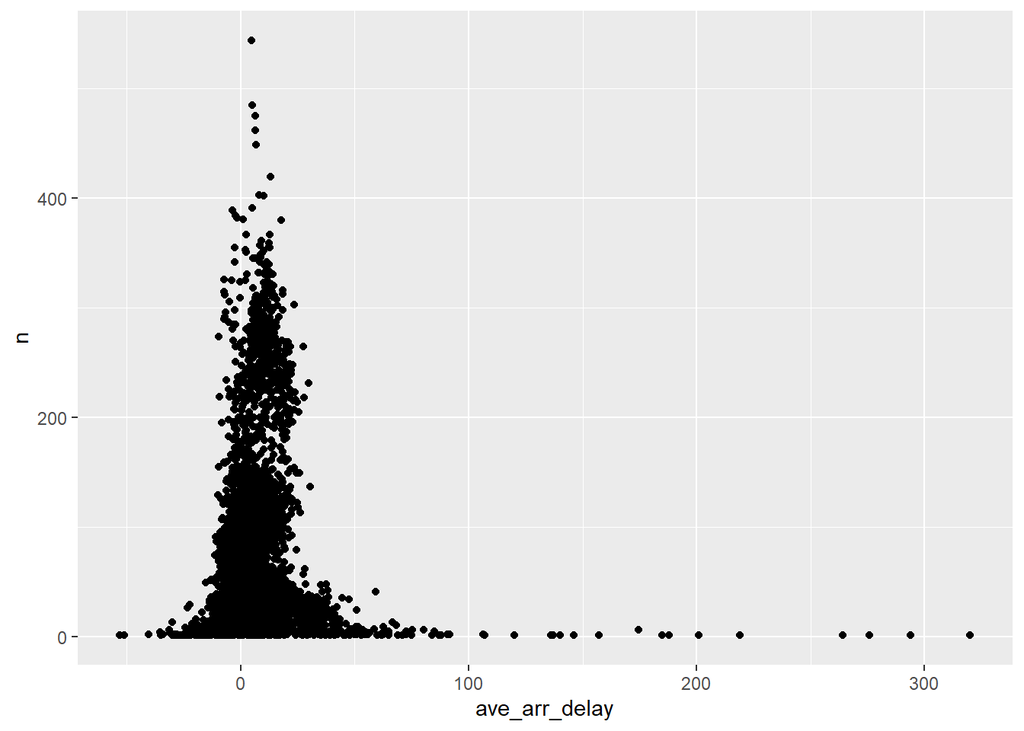

```r
# Your code
flights %>%
  filter(!is.na(tailnum),!is.na(arr_delay)) %>%
  group_by(tailnum) %>%
  summarise(ave_arr_delay =  mean(arr_delay,na.rm = TRUE),n=n()) %>%
  ggplot(aes(x = ave_arr_delay, y = n)) + geom_point()
```

Using the pipe operator follow these steps with the flight data:

- group by month and carrier
- compute the average arrival delay
- plot a line chart with month on the x-axis, average delay on the y-axis
- colour-code each line by carrier or try faceting by carrier

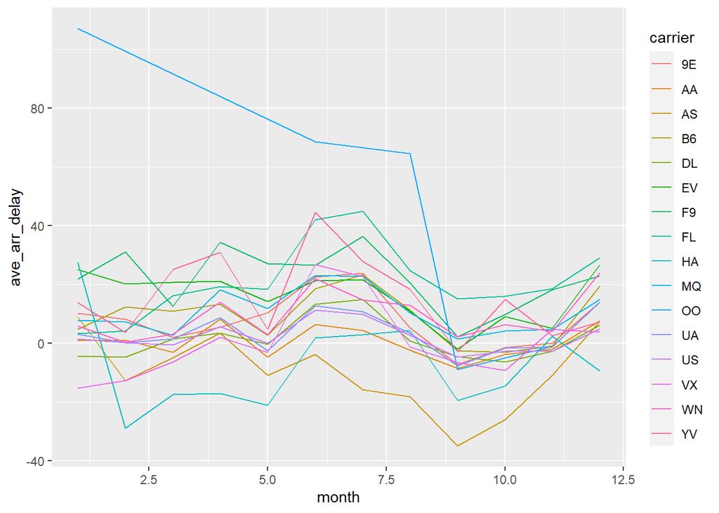

```r
# Your code
flights %>%
  group_by(month,carrier) %>%
  summarise(ave_arr_delay =  mean(arr_delay,na.rm = TRUE)) %>%
  ggplot(mapping=aes(x = month, y = ave_arr_delay,colour=carrier)) + geom_line()
```